# Government Reliance on Privately Held Personal Data

Thesis data, summary statistics, preliminary tests

November 25, 2026

This report and the code behind it were prepared with help from Claude, Anthropic’s AI model. The Data and provenance section describes exactly what Claude did and what I checked.

# Summary of findings

- Research question: how do periods of political or economic crisis change government reliance on privately held personal data, and do those changes persist after the crisis ends?
- Data: 411,779 federal contract transactions (248,893 contracts) from USAspending.gov, FY2008–2026. Of these, 5,236 contracts are purchases of personal data from private firms, together worth $2.71 billion in 2024 dollars.
- National personal-data purchases rose about 35% in FY2020 and stayed at the higher level. Immigration agencies’ purchases rose after the 2025 enforcement surge (randomization p = 0.050).
  - Confirm the 2025 effect with FY2027 data.
- The 2020 rise cannot yet be separated from a general rise in information purchasing such as legal and news research (difference 0.17, p = 0.513).
  - Add FY2002–07 data for the post-9/11 period and more comparison years.
- Most other tests are inconclusive rather than negative, because samples are small and estimates imprecise. For example, the COVID agency estimate is +0.45 with a standard error of 0.59.
  - Replace hand-picked crisis groups with continuous exposure measures, such as COVID emergency-fund spending by agency.
- The results fit a narrower claim: crises raise purchases when they create a mission to find or identify people.
  - Test this refined hypothesis directly in the next round.

# Data and provenance

## How the data were collected

- Downloaded every federal contract transaction FY2008–2026 from the USAspending.gov bulk download API, using three searches: broker vendor names, broker-product keywords, and information-services industry codes (key words generated by Claude and checked by me);
  - matched the 625 firms in the California Data Broker Registry, plus a list of 52 known government data vendors, to federal contractor names;
  - wrote the rules that classify each contract by what was bought;
  - ran blind coding passes on samples of contracts to measure how accurate those rules are.
- I reviewed the vendor matches and exclusions, checked samples of the classified contracts, and verified the totals reported here.
  - Because this is a preliminary step in a larger analysis, I will also hand-code a validation sample myself before the final results.
- Every download is logged with its exact query, date, and row count. The scripts can rebuild every file from scratch. The repository README lists full provenance.

| Source | What it provides | Pulled | Coverage |
| --- | --- | --- | --- |
| USAspending.gov bulk transaction downloads | All contract transactions, with descriptions, agencies, vendors and competition fields | 2026-11-18 | FY2008–FY2026 |
| California Data Broker Registry (cppa.ca.gov) | 625 registered brokers and the types of personal data they hold | 2026-11-18 | 2025 filing |
| Hand-built vendor list | 52 known government data vendors (e.g. LexisNexis, Thomson Reuters CLEAR, Babel Street) | 2026-11-18 | n/a |
| Google, Apple, Microsoft transparency reports | Government legal requests for user data | 2026-11-03 to 11-11 | 2009–2025 |
| Federal grants (USAspending) | Grants funding local police surveillance-data tools, by state | 2026-11-18 | FY2008–FY2026 |

## Raw Data

First 5 rows of the raw keyword-search download (7 of its 297 columns shown)

| action_date | award_id_piid | modification_number | awarding_sub_agency_name | recipient_name | federal_action_obligation | transaction_description |
| --- | --- | --- | --- | --- | --- | --- |
| 2008-12-07 | TLOS011043 | 3 | Bureau of the Fiscal Service | RICOH CORPORATION | 0 | SUPPORT SERVICES |
| 2008-12-07 | TLOS011044 | 3 | Bureau of the Fiscal Service | RICOH CORPORATION | 0 | SUPPORT SERVICES |
| 2008-12-07 | TLOS011045 | 3 | Bureau of the Fiscal Service | RICOH CORPORATION | 0 | SUPPORT SERVICES |
| 2008-12-07 | TLOS011046 | 3 | Bureau of the Fiscal Service | RICOH CORPORATION | 0 | SUPPORT SERVICES |
| 2008-12-07 | TLOS011047 | 3 | Bureau of the Fiscal Service | RICOH CORPORATION | 0 | SUPPORT SERVICES |

- Each row is one contract action: a new award, a modification, or an option exercised. A single contract can have many rows over the years.
- These first five rows show why raw matches cannot be taken at face value. USAspending’s keyword search matched “TLO” (a TransUnion people-search product) to these contract numbers (TLOS…), not to anything bought. The classifier reads the contract text and labels them unrelated.
- After duplicates across the three searches are removed, the combined data hold 411,779 rows.

## Measurement: what counts as personal data

- “Privately held data” according to my proposal is data about a government’s population, acquired by the government through private sources of information, particularly data brokers, rather than collecting information through their existing government infrastructure.
- Central measurement problem: distinguishing government purchases of personal data from broader information technology services.
- Following Milne et al. (2017), I categorize type of private data through its risk to people’s privacy: “data specificity/sensitivity,” with “data risk levels defined.”
- Following those documents, a contract counts as personal data when it buys information about identifiable individuals from a private firm:
  - Specificity: the data is about individual people, such as people search and public records databases, credit and payroll reports, identity verification, and location, license-plate and face-recognition data. Legal research, news and corporate data are excluded because they are not about individuals; they serve as comparison categories in the tests.
  - Source: buying data (purchase channel) and hiring a firm to locate people (locating channel) are separated from the agency buying equipment to collect data itself (own channel, e.g. plate-reader cameras). This is the proposal’s internal-versus-external distinction.
  - Sensitivity: following Milne et al., contracts are flagged for location, biometric, financial, social-media, criminal-records and immigration data.
  - Intensity: personal-data purchases as a share of all federal information-services purchasing.
- Each contract is classified from its text: 1. original award description, 2. modifications, 3. seller. Contracts from multi-product firms with uninformative text (e.g. “SUBSCRIPTION” from RELX) go into a separate ambiguous group, not into personal data.
- Accuracy on a blind holdout of 184 contracts drawn after the rules were frozen:
  - category agreement 88.0%, precision 87.7%, recall about 77.6%;
  - the weak spots are open-source-intelligence analysis contracts and the ambiguous group, which was about one-quarter personal data in the holdout. Key tests are repeated with that share added.

# Summary statistics

- Federal personal-data purchases grew from about $42M a year in FY2008–14 to $112M in FY2015–19, and to $227M in FY2020–26 (2024 dollars).
  - Largest categories: people-search and records databases ($993M), social-media data ($613M), credit and payroll reports ($578M), skip tracing ($256M) and identity verification ($214M).
  - Largest buyers: Department of the Air Force ($523M); U.S. Immigration and Customs Enforcement ($424M); Social Security Administration ($412M); Defense Counterintelligence and Security Agency ($127M); Federal Bureau of Investigation ($112M).
  - Largest sellers: Dataminr ($506M); Equifax Workforce Solutions ($391M); RELX ($302M); West Publishing ($244M); LexisNexis Special Services ($241M).
  - The market is concentrated: the seller HHI averages 1,722 on a 0–10,000 scale, and about 18% of spending is sole-source.
  - By sensitivity flag, the most-purchased data types are financial, immigration, location.
  - Year-to-year swings are driven by single large awards, such as Dataminr’s Defense Department-wide social-media license and two large FY2026 skip-tracing modifications, one of which (Maximus) is overstated and flagged for correction.
  - State-level variation exists only through 257 federal grants (38 states), mostly license-plate readers bought by local police.

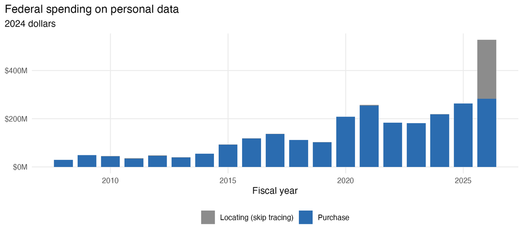

# Preliminary tests

The tests are grouped by method. These are first-pass diagnostics with small samples (19 annual observations, or a handful of treated agencies), meant to show which designs the data can support.

## Interrupted time series

- National purchases jumped about 35% at FY2020 (p = 0.143), and annual growth slowed afterwards (p = 0.003). That fits a lasting step up rather than a temporary spike, but 19 observations cannot pin the step down statistically. Location-data contracts show no post-Carpenter (2018) shift beyond their trend (p = 0.128).
- With a single national series, the cleanest test of “rise and persist” is whether the level breaks from its prior trend at the crisis and whether it later reverts. Newey–West standard errors allow for correlation between adjacent years.

Log spending on trend + FY2020 level shift + post-2020 slope change

| outcome | pre-2020 growth/yr | level shift 2020 | p (shift) | slope change | p (slope) | n |
| --- | --- | --- | --- | --- | --- | --- |
| Purchases | 0.131 | 0.298 | 0.143 | -0.090 | 0.003 | 19 |
| Purchases + ambiguous share | 0.102 | 0.291 | 0.088 | -0.067 | 0.007 | 19 |
| Purchases / all information services | 0.058 | 0.431 | 0.117 | 0.053 | 0.197 | 19 |
| Purchases, excluding FY2026 | 0.131 | 0.333 | 0.090 | -0.111 | 0.002 | 18 |

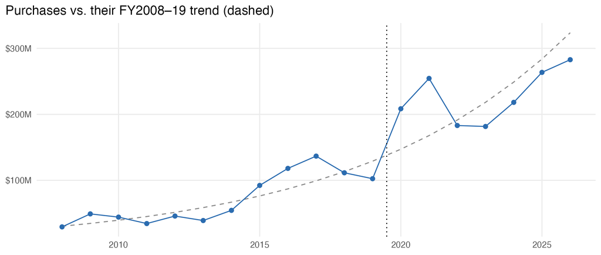

## Difference-in-differences across categories

- Implications: relative to legal and news research bought by the same agencies, personal data shows no distinct post-2020 change (0.17, SE 0.25, p = 0.513). This is the main threat to a crisis-specific story. The corporate-data comparison is too erratic to be informative.
- A national rise could reflect agencies buying more information of every kind. Comparing personal data with similar information that is not about people separates a personal-data effect from general growth.

Post-2020 difference for personal data vs. comparison category; asinh(spending), series and year fixed effects, series-specific trends

| comparison | estimate | SE | p |
| --- | --- | --- | --- |
| Legal and news research (main) | 0.17 | 0.25 | 0.513 |
| Corporate data | 3.03 | 3.26 | 0.366 |
| Both pooled | 1.60 | 1.99 | 0.428 |

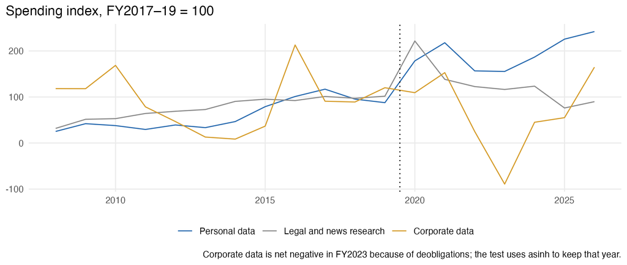

## Agency-level event studies with randomization inference

- No detectable effect for immigration agencies after 2017 (p = 0.759) or for emergency-payment agencies after COVID (p = 0.569), with flat pre-trends. Immigration agencies rose sharply after the 2025 surge (estimate 2.03, p = 0.050), based on two post-event years.
- Comparing exposed agencies with similar unexposed ones, before and after, removes national trends. With only 3–8 treated agencies, randomization inference (reassigning treatment at random 1,000 times) gives more honest p-values than clustered standard errors.

Outcome: asinh(real purchase spending); sub-agency and year fixed effects

| event | treated | controls | estimate | cluster SE | randomization p | pre-trend slope | pre-trend p |
| --- | --- | --- | --- | --- | --- | --- | --- |
| Immigration agencies, FY2017 | 3 | 10 | 0.30 | 0.53 | 0.759 | 0.50 | 0.317 |
| Immigration agencies, FY2025 | 3 | 10 | 2.03 | 0.78 | 0.050 | 0.24 | 0.131 |
| Emergency-payment agencies, FY2020 | 8 | 98 | 0.45 | 0.59 | 0.569 | -0.24 | 0.496 |

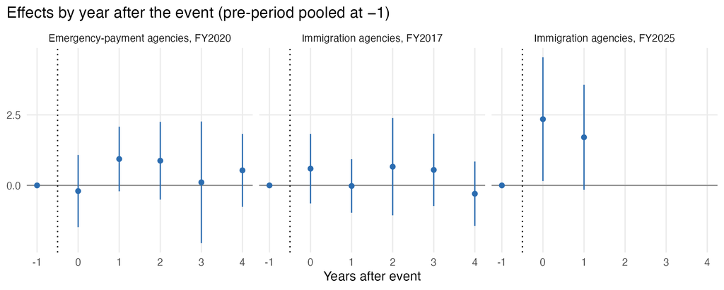

## Persistence regressions

- About half of an agency’s COVID-era spending level carries into FY2022–24 (0.49). But the two non-crisis comparison windows give 0.22 and 1, so crisis persistence cannot yet be distinguished from ordinary year-to-year persistence.
- Persistence is the second half of the research question. Regressing the later level on the crisis level while holding the pre-crisis level fixed measures how much of a crisis change sticks. Repeating it in non-crisis windows provides the benchmark.

log(post) on log(crisis), controlling for log(pre); sub-agencies with pre-period spending

| windows | carry-forward | SE | p | n |
| --- | --- | --- | --- | --- |
| Comparison: 2009–11 / 2012–13 / 2014–16 | 0.22 | 0.28 | 0.431 | 40 |
| Comparison: 2012–14 / 2015–16 / 2017–19 | 1.00 | 0.06 | <0.001 | 39 |
| COVID: 2017–19 / 2020–21 / 2022–24 | 0.49 | 0.19 | 0.013 | 45 |

## Tie-survival logit

- Firm–agency relationships formed during COVID are about as likely to be active two years later as earlier ones (odds ratio 1.04, p = 0.896). The size of the first purchase predicts survival much better.
- Dependence on particular firms is a network question. If crises create lasting reliance, relationships formed in a crisis should outlast ordinary ones.

Two-year survival of firm–sub-agency ties

| cohort | ties | active 2 years later |
| --- | --- | --- |
| Formed FY2020–21 | 90 | 0.51 |
| Formed FY2010–19 | 445 | 0.48 |
| Formed FY2022–23 | 62 | 0.31 |

## Linear probability model of procurement mode

- Crisis years don’t show more single source purchasing of personal data (-5.4 percentage points, p = 0.135). The base rate is 39%.
- If crises push agencies to buy data quickly, they should skip competition more often. Comparing contracts within the same agency, with agency fixed effects, isolates the timing.

## Correlation with compelled requests

- Yearly changes in purchases and in U.S. legal requests to Google are weakly negatively correlated (r = -0.32, p = 0.246). That is a faint hint that buying substitutes for compelled requests, not a result.
- Legal requests require legal process and purchases do not. If agencies substitute one channel for the other, the two series should move in opposite directions.